# Lab_Data Handling_V SAI PRANAV_U01783582

```r
library(tidyverse)
```

```r
library(nycflights13)
```

**Exercise_1**

```r
flights
```

| year | month | day | dep_time | sched_dep_time | dep_delay | arr_time | sched_arr_time | arr_delay | carrier | flight | tailnum | origin | dest | air_time | distance | hour | minute | time_hour |
| --- | --- | --- | --- | --- | --- | --- | --- | --- | --- | --- | --- | --- | --- | --- | --- | --- | --- | --- |
| 2013 | 1 | 1 | 517 | 515 | 2 | 830 | 819 | 11 | UA | 1545 | N14228 | EWR | IAH | 227 | 1400 | 5 | 15 | 2013-01-01 05:00:00 |
| 2013 | 1 | 1 | 533 | 529 | 4 | 850 | 830 | 20 | UA | 1714 | N24211 | LGA | IAH | 227 | 1416 | 5 | 29 | 2013-01-01 05:00:00 |
| 2013 | 1 | 1 | 542 | 540 | 2 | 923 | 850 | 33 | AA | 1141 | N619AA | JFK | MIA | 160 | 1089 | 5 | 40 | 2013-01-01 05:00:00 |
| 2013 | 1 | 1 | 544 | 545 | -1 | 1004 | 1022 | -18 | B6 | 725 | N804JB | JFK | BQN | 183 | 1576 | 5 | 45 | 2013-01-01 05:00:00 |
| 2013 | 1 | 1 | 554 | 600 | -6 | 812 | 837 | -25 | DL | 461 | N668DN | LGA | ATL | 116 | 762 | 6 | 0 | 2013-01-01 06:00:00 |
| 2013 | 1 | 1 | 554 | 558 | -4 | 740 | 728 | 12 | UA | 1696 | N39463 | EWR | ORD | 150 | 719 | 5 | 58 | 2013-01-01 05:00:00 |
| 2013 | 1 | 1 | 555 | 600 | -5 | 913 | 854 | 19 | B6 | 507 | N516JB | EWR | FLL | 158 | 1065 | 6 | 0 | 2013-01-01 06:00:00 |
| 2013 | 1 | 1 | 557 | 600 | -3 | 709 | 723 | -14 | EV | 5708 | N829AS | LGA | IAD | 53 | 229 | 6 | 0 | 2013-01-01 06:00:00 |
| 2013 | 1 | 1 | 557 | 600 | -3 | 838 | 846 | -8 | B6 | 79 | N593JB | JFK | MCO | 140 | 944 | 6 | 0 | 2013-01-01 06:00:00 |
| 2013 | 1 | 1 | 558 | 600 | -2 | 753 | 745 | 8 | AA | 301 | N3ALAA | LGA | ORD | 138 | 733 | 6 | 0 | 2013-01-01 06:00:00 |

[output cut: 990 more lines]

```r
names(flights)
```

```
 [1] "year"           "month"          "day"            "dep_time"       "sched_dep_time" "dep_delay"
 [7] "arr_time"       "sched_arr_time" "arr_delay"      "carrier"        "flight"         "tailnum"
[13] "origin"         "dest"           "air_time"       "distance"       "hour"           "minute"
[19] "time_hour"
```

```r
glimpse(flights)
```

```
Rows: 336,776
Columns: 19
$ year           <int> 2013, 2013, 2013, 2013, 2013, 2013, 2013, 2013, 2013, 2013, 2013, 2013, 2013, 2013, 201~
$ month          <int> 1, 1, 1, 1, 1, 1, 1, 1, 1, 1, 1, 1, 1, 1, 1, 1, 1, 1, 1, 1, 1, 1, 1, 1, 1, 1, 1, 1, 1, ~
$ day            <int> 1, 1, 1, 1, 1, 1, 1, 1, 1, 1, 1, 1, 1, 1, 1, 1, 1, 1, 1, 1, 1, 1, 1, 1, 1, 1, 1, 1, 1, ~
$ dep_time       <int> 517, 533, 542, 544, 554, 554, 555, 557, 557, 558, 558, 558, 558, 558, 559, 559, 559, 60~
$ sched_dep_time <int> 515, 529, 540, 545, 600, 558, 600, 600, 600, 600, 600, 600, 600, 600, 600, 559, 600, 60~
$ dep_delay      <dbl> 2, 4, 2, -1, -6, -4, -5, -3, -3, -2, -2, -2, -2, -2, -1, 0, -1, 0, 0, 1, -8, -3, -4, -4~
$ arr_time       <int> 830, 850, 923, 1004, 812, 740, 913, 709, 838, 753, 849, 853, 924, 923, 941, 702, 854, 8~
$ sched_arr_time <int> 819, 830, 850, 1022, 837, 728, 854, 723, 846, 745, 851, 856, 917, 937, 910, 706, 902, 8~
$ arr_delay      <dbl> 11, 20, 33, -18, -25, 12, 19, -14, -8, 8, -2, -3, 7, -14, 31, -4, -8, -7, 12, -6, -8, 1~
$ carrier        <chr> "UA", "UA", "AA", "B6", "DL", "UA", "B6", "EV", "B6", "AA", "B6", "B6", "UA", "UA", "AA~
$ flight         <int> 1545, 1714, 1141, 725, 461, 1696, 507, 5708, 79, 301, 49, 71, 194, 1124, 707, 1806, 118~
$ tailnum        <chr> "N14228", "N24211", "N619AA", "N804JB", "N668DN", "N39463", "N516JB", "N829AS", "N593JB~
$ origin         <chr> "EWR", "LGA", "JFK", "JFK", "LGA", "EWR", "EWR", "LGA", "JFK", "LGA", "JFK", "JFK", "JF~
$ dest           <chr> "IAH", "IAH", "MIA", "BQN", "ATL", "ORD", "FLL", "IAD", "MCO", "ORD", "PBI", "TPA", "LA~
$ air_time       <dbl> 227, 227, 160, 183, 116, 150, 158, 53, 140, 138, 149, 158, 345, 361, 257, 44, 337, 152,~
$ distance       <dbl> 1400, 1416, 1089, 1576, 762, 719, 1065, 229, 944, 733, 1028, 1005, 2475, 2565, 1389, 18~
$ hour           <dbl> 5, 5, 5, 5, 6, 5, 6, 6, 6, 6, 6, 6, 6, 6, 6, 5, 6, 6, 6, 6, 6, 6, 6, 6, 6, 6, 6, 6, 6, ~
$ minute         <dbl> 15, 29, 40, 45, 0, 58, 0, 0, 0, 0, 0, 0, 0, 0, 0, 59, 0, 0, 0, 0, 10, 5, 10, 10, 7, 0, ~
$ time_hour      <dttm> 2013-01-01 05:00:00, 2013-01-01 05:00:00, 2013-01-01 05:00:00, 2013-01-01 05:00:00, 20~
```

I have used names and glimpse to explore the data.

**Exercise_2**

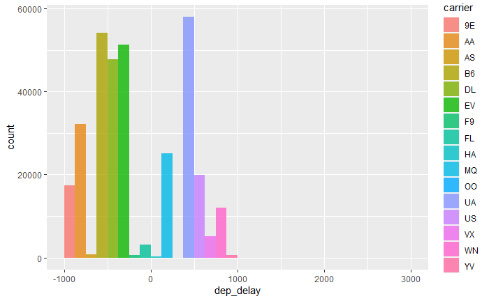

```r
ggplot(flights, aes(dep_delay, fill = carrier)) +
  geom_histogram(position = "dodge",alpha = 0.8, binwidth = 2000)
```

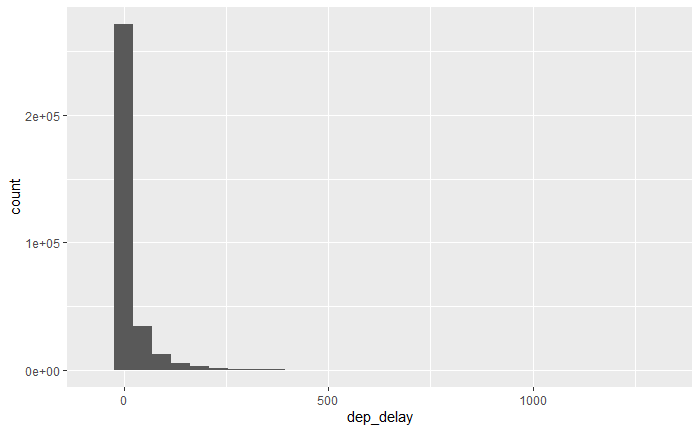

```r
ggplot(flights, aes(dep_delay)) +
  geom_histogram()
```

As you can see the difference between plot 1 and plot 2 that we are able to extract information on which flight had more number of delayed departures but in second plot we cannot say that

**Exercise_3**

```r
flights_LAX <- flights %>%
                filter(dest == "LAX")
flights_LAX
```

| year | month | day | dep_time | sched_dep_time | dep_delay | arr_time | sched_arr_time | arr_delay | carrier | flight | tailnum | origin | dest | air_time | distance | hour | minute | time_hour |
| --- | --- | --- | --- | --- | --- | --- | --- | --- | --- | --- | --- | --- | --- | --- | --- | --- | --- | --- |
| 2013 | 1 | 1 | 558 | 600 | -2 | 924 | 917 | 7 | UA | 194 | N29129 | JFK | LAX | 345 | 2475 | 6 | 0 | 2013-01-01 06:00:00 |
| 2013 | 1 | 1 | 628 | 630 | -2 | 1016 | 947 | 29 | UA | 1665 | N33289 | EWR | LAX | 366 | 2454 | 6 | 30 | 2013-01-01 06:00:00 |
| 2013 | 1 | 1 | 658 | 700 | -2 | 1027 | 1025 | 2 | VX | 399 | N627VA | JFK | LAX | 361 | 2475 | 7 | 0 | 2013-01-01 07:00:00 |
| 2013 | 1 | 1 | 702 | 700 | 2 | 1058 | 1014 | 44 | B6 | 671 | N779JB | JFK | LAX | 381 | 2475 | 7 | 0 | 2013-01-01 07:00:00 |
| 2013 | 1 | 1 | 743 | 730 | 13 | 1107 | 1100 | 7 | AA | 33 | N338AA | JFK | LAX | 358 | 2475 | 7 | 30 | 2013-01-01 07:00:00 |
| 2013 | 1 | 1 | 828 | 823 | 5 | 1150 | 1143 | 7 | UA | 1506 | N76528 | EWR | LAX | 359 | 2454 | 8 | 23 | 2013-01-01 08:00:00 |
| 2013 | 1 | 1 | 829 | 830 | -1 | 1152 | 1200 | -8 | UA | 443 | N554UA | JFK | LAX | 360 | 2475 | 8 | 30 | 2013-01-01 08:00:00 |
| 2013 | 1 | 1 | 856 | 900 | -4 | 1226 | 1220 | 6 | AA | 1 | N324AA | JFK | LAX | 358 | 2475 | 9 | 0 | 2013-01-01 09:00:00 |
| 2013 | 1 | 1 | 859 | 900 | -1 | 1223 | 1225 | -2 | VX | 407 | N846VA | JFK | LAX | 359 | 2475 | 9 | 0 | 2013-01-01 09:00:00 |
| 2013 | 1 | 1 | 921 | 900 | 21 | 1237 | 1227 | 10 | DL | 120 | N713TW | JFK | LAX | 333 | 2475 | 9 | 0 | 2013-01-01 09:00:00 |

[output cut: 990 more lines]

Here the data set ‘flights_LAX’ all the info about the flights with the destination = LAX.

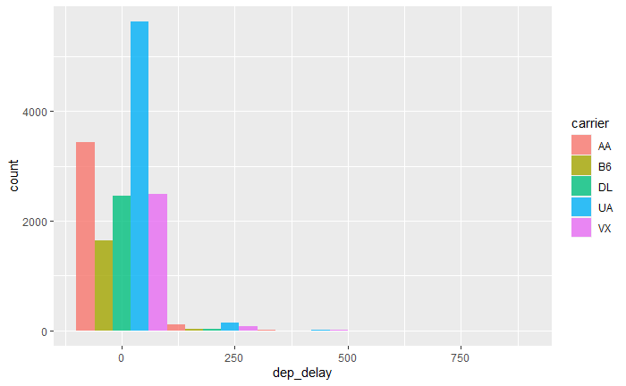

```r
ggplot(flights_LAX, aes(dep_delay, fill = carrier)) +
  geom_histogram(position = "dodge",alpha = 0.8, binwidth = 200)
```

As you can see clearly that flight carrier “UA” has more number of delays in departure then “AA”, and then “VX”, so on.

**Exercise_4**

```r
flights %>%
  group_by(dep_delay) %>%
  summarize(mean_dd = mean(dep_delay),
            median_dd = median(dep_delay),
            n = n())
```

| dep_delay | mean_dd | median_dd | n |
| --- | --- | --- | --- |
| -43 | -43 | -43 | 1 |
| -33 | -33 | -33 | 1 |
| -32 | -32 | -32 | 1 |
| -30 | -30 | -30 | 1 |
| -27 | -27 | -27 | 1 |
| -26 | -26 | -26 | 1 |
| -25 | -25 | -25 | 2 |
| -24 | -24 | -24 | 4 |
| -23 | -23 | -23 | 6 |
| -22 | -22 | -22 | 11 |

[output cut: 518 more lines]

```r
NA
NA
```

Here as you can see we get the mean median as well as th count too.

**Exercise_5**

```r
sfo_feb_flights <- flights %>%
                      filter(dest=='SFO', month == 2)
sfo_feb_flights
```

| year | month | day | dep_time | sched_dep_time | dep_delay | arr_time | sched_arr_time | arr_delay | carrier | flight | tailnum | origin | dest | air_time | distance | hour | minute | time_hour |
| --- | --- | --- | --- | --- | --- | --- | --- | --- | --- | --- | --- | --- | --- | --- | --- | --- | --- | --- |
| 2013 | 2 | 1 | 559 | 600 | -1 | 923 | 925 | -2 | UA | 303 | N508UA | JFK | SFO | 358 | 2586 | 6 | 0 | 2013-02-01 06:00:00 |
| 2013 | 2 | 1 | 631 | 635 | -4 | 946 | 1002 | -16 | UA | 421 | N818UA | EWR | SFO | 352 | 2565 | 6 | 35 | 2013-02-01 06:00:00 |
| 2013 | 2 | 1 | 653 | 700 | -7 | 1023 | 1045 | -22 | DL | 1865 | N713TW | JFK | SFO | 349 | 2586 | 7 | 0 | 2013-02-01 07:00:00 |
| 2013 | 2 | 1 | 704 | 715 | -11 | 1040 | 1040 | 0 | UA | 799 | N557UA | JFK | SFO | 358 | 2586 | 7 | 15 | 2013-02-01 07:00:00 |
| 2013 | 2 | 1 | 723 | 730 | -7 | 1055 | 1115 | -20 | VX | 11 | N839VA | JFK | SFO | 358 | 2586 | 7 | 30 | 2013-02-01 07:00:00 |
| 2013 | 2 | 1 | 754 | 800 | -6 | 1119 | 1125 | -6 | UA | 397 | N525UA | JFK | SFO | 349 | 2586 | 8 | 0 | 2013-02-01 08:00:00 |
| 2013 | 2 | 1 | 756 | 747 | 9 | 1129 | 1126 | 3 | B6 | 643 | N789JB | JFK | SFO | 369 | 2586 | 7 | 47 | 2013-02-01 07:00:00 |
| 2013 | 2 | 1 | 802 | 745 | 17 | 1125 | 1125 | 0 | AA | 59 | N353AA | JFK | SFO | 356 | 2586 | 7 | 45 | 2013-02-01 07:00:00 |
| 2013 | 2 | 1 | 951 | 1000 | -9 | 1316 | 1341 | -25 | DL | 1765 | N704X | JFK | SFO | 352 | 2586 | 10 | 0 | 2013-02-01 10:00:00 |
| 2013 | 2 | 1 | 1019 | 835 | 104 | 1330 | 1215 | 75 | UA | 1480 | N17229 | EWR | SFO | 353 | 2565 | 8 | 35 | 2013-02-01 08:00:00 |

[output cut: 781 more lines]

All the data of flights reaching to SFO is in “sfo_feb_flights”

```r
sfo_feb_flights %>%
  group_by(flight, carrier) %>%
  count(flight) %>%
  arrange(flight)
```

| flight | carrier | n |
| --- | --- | --- |
| 11 | VX | 28 |
| 23 | VX | 24 |
| 27 | VX | 28 |
| 29 | VX | 24 |
| 31 | DL | 27 |
| 55 | UA | 1 |
| 59 | AA | 28 |
| 81 | UA | 3 |
| 85 | AA | 28 |
| 106 | UA | 1 |

[output cut: 81 more lines]

In the above chunk we got the count of the flights going to SFO in a sorted order performed on flights.

**Exercise_6**

```r
summary(sfo_feb_flights)
```

```
      year          month        day           dep_time    sched_dep_time   dep_delay          arr_time
 Min.   :2013   Min.   :2   Min.   : 1.00   Min.   : 553   Min.   : 559   Min.   :-13.000   Min.   :  11
 1st Qu.:2013   1st Qu.:2   1st Qu.: 8.00   1st Qu.: 803   1st Qu.: 802   1st Qu.: -4.000   1st Qu.:1136
 Median :2013   Median :2   Median :15.00   Median :1220   Median :1221   Median : -1.000   Median :1542
 Mean   :2013   Mean   :2   Mean   :14.59   Mean   :1272   Mean   :1267   Mean   :  6.131   Mean   :1600
 3rd Qu.:2013   3rd Qu.:2   3rd Qu.:22.00   3rd Qu.:1722   3rd Qu.:1725   3rd Qu.:  4.000   3rd Qu.:2038
 Max.   :2013   Max.   :2   Max.   :28.00   Max.   :2159   Max.   :2000   Max.   :255.000   Max.   :2345
                                            NA's   :29                    NA's   :29        NA's   :29
 sched_arr_time   arr_delay         carrier              flight         tailnum             origin
 Min.   : 925   Min.   :-69.000   Length:791         Min.   :  11.0   Length:791         Length:791
 1st Qu.:1128   1st Qu.:-28.000   Class :character   1st Qu.: 177.0   Class :character   Class :character
 Median :1555   Median :-13.000   Mode  :character   Median : 512.0   Mode  :character   Mode  :character
 Mean   :1626   Mean   : -9.143                      Mean   : 690.9
 3rd Qu.:2050   3rd Qu.:  1.000                      3rd Qu.:1204.0
 Max.   :2335   Max.   :205.000                      Max.   :2126.0
                NA's   :29
     dest              air_time        distance         hour           minute
 Length:791         Min.   :307.0   Min.   :2565   Min.   : 5.00   Min.   : 0.00
 Class :character   1st Qu.:342.0   1st Qu.:2586   1st Qu.: 8.00   1st Qu.: 5.00
 Mode  :character   Median :352.0   Median :2586   Median :12.00   Median :30.00
                    Mean   :350.8   Mean   :2581   Mean   :12.42   Mean   :25.43
                    3rd Qu.:360.0   3rd Qu.:2586   3rd Qu.:17.00   3rd Qu.:35.00
                    Max.   :422.0   Max.   :2586   Max.   :20.00   Max.   :59.00
                    NA's   :29
   time_hour
 Min.   :2013-02-01 06:00:00
 1st Qu.:2013-02-08 06:00:00
 Median :2013-02-15 06:00:00
 Mean   :2013-02-15 02:35:20
 3rd Qu.:2013-02-22 06:00:00
 Max.   :2013-02-28 19:00:00
```

As you can see that there are NA’s in dep_delay, arr_delay. We have to get rid of them in-order to work with summarize.

```r
sfo_feb_flights_NA_rem <- na.omit(sfo_feb_flights)
```

I have stored the data frame without NA’s into sfo_feb_flights_NA_rem

```r
summary(sfo_feb_flights_NA_rem)
```

```
      year          month        day           dep_time    sched_dep_time   dep_delay          arr_time
 Min.   :2013   Min.   :2   Min.   : 1.00   Min.   : 553   Min.   : 559   Min.   :-13.000   Min.   :  11
 1st Qu.:2013   1st Qu.:2   1st Qu.: 7.00   1st Qu.: 803   1st Qu.: 804   1st Qu.: -4.000   1st Qu.:1136
 Median :2013   Median :2   Median :15.00   Median :1220   Median :1221   Median : -1.000   Median :1542
 Mean   :2013   Mean   :2   Mean   :14.77   Mean   :1272   Mean   :1267   Mean   :  6.131   Mean   :1600
 3rd Qu.:2013   3rd Qu.:2   3rd Qu.:22.00   3rd Qu.:1722   3rd Qu.:1725   3rd Qu.:  4.000   3rd Qu.:2038
 Max.   :2013   Max.   :2   Max.   :28.00   Max.   :2159   Max.   :2000   Max.   :255.000   Max.   :2345
 sched_arr_time   arr_delay         carrier              flight         tailnum             origin
 Min.   : 925   Min.   :-69.000   Length:762         Min.   :  11.0   Length:762         Length:762
 1st Qu.:1129   1st Qu.:-28.000   Class :character   1st Qu.: 177.0   Class :character   Class :character
 Median :1555   Median :-13.000   Mode  :character   Median : 512.0   Mode  :character   Mode  :character
 Mean   :1626   Mean   : -9.143                      Mean   : 694.1
 3rd Qu.:2050   3rd Qu.:  1.000                      3rd Qu.:1214.0
 Max.   :2335   Max.   :205.000                      Max.   :2126.0
     dest              air_time        distance         hour           minute       time_hour
 Length:762         Min.   :307.0   Min.   :2565   Min.   : 5.00   Min.   : 0.0   Min.   :2013-02-01 06:00:00
 Class :character   1st Qu.:342.0   1st Qu.:2586   1st Qu.: 8.00   1st Qu.: 5.0   1st Qu.:2013-02-07 17:00:00
 Mode  :character   Median :352.0   Median :2586   Median :12.00   Median :30.0   Median :2013-02-15 10:30:00
                    Mean   :350.8   Mean   :2581   Mean   :12.42   Mean   :25.4   Mean   :2013-02-15 06:54:19
                    3rd Qu.:360.0   3rd Qu.:2586   3rd Qu.:17.00   3rd Qu.:35.0   3rd Qu.:2013-02-22 07:00:00
                    Max.   :422.0   Max.   :2586   Max.   :20.00   Max.   :59.0   Max.   :2013-02-28 19:00:00
```

All the NA’s have been removed.

```r
sfo_feb_flights_NA_rem %>%
  group_by(carrier) %>%
  summarize(median_dd = median(arr_delay),
            iqr_dd = IQR(arr_delay))
```

| carrier | median_dd | iqr_dd |
| --- | --- | --- |
| AA | -7 | 35.0 |
| B6 | -11 | 25.5 |
| DL | -24 | 27.5 |
| UA | -9 | 27.0 |
| VX | -20 | 23.0 |

The above Output is the median and the iqr grouped by carrier as requested.

**Exercise_7**

```r
summary(flights)
```

```
      year          month             day           dep_time    sched_dep_time   dep_delay          arr_time
 Min.   :2013   Min.   : 1.000   Min.   : 1.00   Min.   :   1   Min.   : 106   Min.   : -43.00   Min.   :   1
 1st Qu.:2013   1st Qu.: 4.000   1st Qu.: 8.00   1st Qu.: 907   1st Qu.: 906   1st Qu.:  -5.00   1st Qu.:1104
 Median :2013   Median : 7.000   Median :16.00   Median :1401   Median :1359   Median :  -2.00   Median :1535
 Mean   :2013   Mean   : 6.549   Mean   :15.71   Mean   :1349   Mean   :1344   Mean   :  12.64   Mean   :1502
 3rd Qu.:2013   3rd Qu.:10.000   3rd Qu.:23.00   3rd Qu.:1744   3rd Qu.:1729   3rd Qu.:  11.00   3rd Qu.:1940
 Max.   :2013   Max.   :12.000   Max.   :31.00   Max.   :2400   Max.   :2359   Max.   :1301.00   Max.   :2400
                                                 NA's   :8255                  NA's   :8255      NA's   :8713
 sched_arr_time   arr_delay          carrier              flight       tailnum             origin
 Min.   :   1   Min.   : -86.000   Length:336776      Min.   :   1   Length:336776      Length:336776
 1st Qu.:1124   1st Qu.: -17.000   Class :character   1st Qu.: 553   Class :character   Class :character
 Median :1556   Median :  -5.000   Mode  :character   Median :1496   Mode  :character   Mode  :character
 Mean   :1536   Mean   :   6.895                      Mean   :1972
 3rd Qu.:1945   3rd Qu.:  14.000                      3rd Qu.:3465
 Max.   :2359   Max.   :1272.000                      Max.   :8500
                NA's   :9430
     dest              air_time        distance         hour           minute
 Length:336776      Min.   : 20.0   Min.   :  17   Min.   : 1.00   Min.   : 0.00
 Class :character   1st Qu.: 82.0   1st Qu.: 502   1st Qu.: 9.00   1st Qu.: 8.00
 Mode  :character   Median :129.0   Median : 872   Median :13.00   Median :29.00
                    Mean   :150.7   Mean   :1040   Mean   :13.18   Mean   :26.23
                    3rd Qu.:192.0   3rd Qu.:1389   3rd Qu.:17.00   3rd Qu.:44.00
                    Max.   :695.0   Max.   :4983   Max.   :23.00   Max.   :59.00
                    NA's   :9430
   time_hour
 Min.   :2013-01-01 05:00:00
 1st Qu.:2013-04-04 13:00:00
 Median :2013-07-03 10:00:00
 Mean   :2013-07-03 05:22:54
 3rd Qu.:2013-10-01 07:00:00
 Max.   :2013-12-31 23:00:00
```

We will clear the NA’s from the dataframe and store it in a new dataframe as we did earlier.

```r
flights_NA_rem <- na.omit(flights)
```

```r
summary(flights_NA_rem)
```

```
      year          month             day           dep_time    sched_dep_time   dep_delay          arr_time
 Min.   :2013   Min.   : 1.000   Min.   : 1.00   Min.   :   1   Min.   : 500   Min.   : -43.00   Min.   :   1
 1st Qu.:2013   1st Qu.: 4.000   1st Qu.: 8.00   1st Qu.: 907   1st Qu.: 905   1st Qu.:  -5.00   1st Qu.:1104
 Median :2013   Median : 7.000   Median :16.00   Median :1400   Median :1355   Median :  -2.00   Median :1535
 Mean   :2013   Mean   : 6.565   Mean   :15.74   Mean   :1349   Mean   :1340   Mean   :  12.56   Mean   :1502
 3rd Qu.:2013   3rd Qu.:10.000   3rd Qu.:23.00   3rd Qu.:1744   3rd Qu.:1729   3rd Qu.:  11.00   3rd Qu.:1940
 Max.   :2013   Max.   :12.000   Max.   :31.00   Max.   :2400   Max.   :2359   Max.   :1301.00   Max.   :2400
 sched_arr_time   arr_delay          carrier              flight       tailnum             origin
 Min.   :   1   Min.   : -86.000   Length:327346      Min.   :   1   Length:327346      Length:327346
 1st Qu.:1122   1st Qu.: -17.000   Class :character   1st Qu.: 544   Class :character   Class :character
 Median :1554   Median :  -5.000   Mode  :character   Median :1467   Mode  :character   Mode  :character
 Mean   :1533   Mean   :   6.895                      Mean   :1943
 3rd Qu.:1944   3rd Qu.:  14.000                      3rd Qu.:3412
 Max.   :2359   Max.   :1272.000                      Max.   :8500
     dest              air_time        distance         hour           minute
 Length:327346      Min.   : 20.0   Min.   :  80   Min.   : 5.00   Min.   : 0.00
 Class :character   1st Qu.: 82.0   1st Qu.: 509   1st Qu.: 9.00   1st Qu.: 8.00
 Mode  :character   Median :129.0   Median : 888   Median :13.00   Median :29.00
                    Mean   :150.7   Mean   :1048   Mean   :13.14   Mean   :26.23
                    3rd Qu.:192.0   3rd Qu.:1389   3rd Qu.:17.00   3rd Qu.:44.00
                    Max.   :695.0   Max.   :4983   Max.   :23.00   Max.   :59.00
   time_hour
 Min.   :2013-01-01 05:00:00
 1st Qu.:2013-04-05 06:00:00
 Median :2013-07-04 09:00:00
 Mean   :2013-07-03 17:56:45
 3rd Qu.:2013-10-01 18:00:00
 Max.   :2013-12-31 23:00:00
```

As you can see there are no NA’s in the new dataframe.

```r
flights_NA_rem %>%
  group_by(month) %>%
  summarize(mean_dd = mean(dep_delay))%>%
  arrange(desc(mean_dd))
```

| month | mean_dd |
| --- | --- |
| 7 | 21.522179 |
| 6 | 20.725614 |
| 12 | 16.482161 |
| 4 | 13.849187 |
| 3 | 13.164289 |
| 5 | 12.891709 |
| 8 | 12.570524 |
| 2 | 10.760239 |
| 1 | 9.985491 |
| 9 | 6.630285 |

[output cut: 2 more lines]

As it was asked in the question to arrange the average in descending order, I have arranged it that way.

**Exercise_8**

```r
flights_avg_speed <- flights %>%
                      mutate(avg_speed = distance/(air_time/60))

flights_avg_speed
```

| year | month | day | dep_time | sched_dep_time | dep_delay | arr_time | sched_arr_time | arr_delay | carrier | flight | tailnum | origin | dest | air_time | distance | hour | minute | time_hour | avg_speed |
| --- | --- | --- | --- | --- | --- | --- | --- | --- | --- | --- | --- | --- | --- | --- | --- | --- | --- | --- | --- |
| 2013 | 1 | 1 | 517 | 515 | 2 | 830 | 819 | 11 | UA | 1545 | N14228 | EWR | IAH | 227 | 1400 | 5 | 15 | 2013-01-01 05:00:00 | 370.0441 |
| 2013 | 1 | 1 | 533 | 529 | 4 | 850 | 830 | 20 | UA | 1714 | N24211 | LGA | IAH | 227 | 1416 | 5 | 29 | 2013-01-01 05:00:00 | 374.2731 |
| 2013 | 1 | 1 | 542 | 540 | 2 | 923 | 850 | 33 | AA | 1141 | N619AA | JFK | MIA | 160 | 1089 | 5 | 40 | 2013-01-01 05:00:00 | 408.3750 |
| 2013 | 1 | 1 | 544 | 545 | -1 | 1004 | 1022 | -18 | B6 | 725 | N804JB | JFK | BQN | 183 | 1576 | 5 | 45 | 2013-01-01 05:00:00 | 516.7213 |
| 2013 | 1 | 1 | 554 | 600 | -6 | 812 | 837 | -25 | DL | 461 | N668DN | LGA | ATL | 116 | 762 | 6 | 0 | 2013-01-01 06:00:00 | 394.1379 |
| 2013 | 1 | 1 | 554 | 558 | -4 | 740 | 728 | 12 | UA | 1696 | N39463 | EWR | ORD | 150 | 719 | 5 | 58 | 2013-01-01 05:00:00 | 287.6000 |
| 2013 | 1 | 1 | 555 | 600 | -5 | 913 | 854 | 19 | B6 | 507 | N516JB | EWR | FLL | 158 | 1065 | 6 | 0 | 2013-01-01 06:00:00 | 404.4304 |
| 2013 | 1 | 1 | 557 | 600 | -3 | 709 | 723 | -14 | EV | 5708 | N829AS | LGA | IAD | 53 | 229 | 6 | 0 | 2013-01-01 06:00:00 | 259.2453 |
| 2013 | 1 | 1 | 557 | 600 | -3 | 838 | 846 | -8 | B6 | 79 | N593JB | JFK | MCO | 140 | 944 | 6 | 0 | 2013-01-01 06:00:00 | 404.5714 |
| 2013 | 1 | 1 | 558 | 600 | -2 | 753 | 745 | 8 | AA | 301 | N3ALAA | LGA | ORD | 138 | 733 | 6 | 0 | 2013-01-01 06:00:00 | 318.6957 |

[output cut: 990 more lines]

```r
NA
```

Flights_avg speed has the data with average speed as a new column in it.

**Exercise_9**

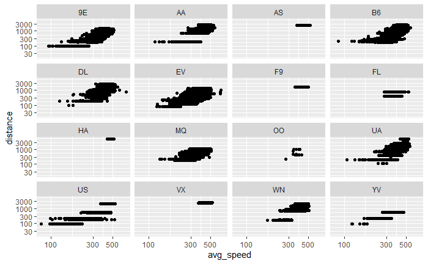

```r
ggplot(flights_avg_speed, aes(avg_speed,distance), color = flight) +
  geom_point() +
  scale_x_log10() +
  scale_y_log10() +
  facet_wrap(~carrier)
```

The above graph is faceted based on the carrier so you can see the scatter plots of respective carriers.